# Descriptive statistics: mean, median, mode, variance, standard deviation.

```python
import pandas as pd
import numpy as np
import matplotlib.pyplot as plt
import seaborn as sns
```

```python
data = pd.read_csv('marketing_company_data.csv')
data
```

|  | Campaign ID | Budget (USD) | Clicks | Impressions | Conversions | Region | Date |
| --- | --- | --- | --- | --- | --- | --- | --- |
| 0 | 1 | 8270 | 1943 | 92747 | 386 | South | 2023-01-01 |
| 1 | 2 | 1860 | 588 | 63752 | 460 | South | 2023-01-02 |
| 2 | 3 | 6390 | 3076 | 57573 | 347 | East | 2023-01-03 |
| 3 | 4 | 6191 | 2059 | 60101 | 189 | East | 2023-01-04 |
| 4 | 5 | 6734 | 2485 | 27646 | 190 | East | 2023-01-05 |
| ... | ... | ... | ... | ... | ... | ... | ... |
| 195 | 196 | 7546 | 4648 | 14116 | 251 | North | 2023-07-15 |
| 196 | 197 | 2986 | 3059 | 26470 | 225 | North | 2023-07-16 |
| 197 | 198 | 9338 | 2365 | 43344 | 293 | South | 2023-07-17 |
| 198 | 199 | 3911 | 2579 | 43918 | 305 | North | 2023-07-18 |
| 199 | 200 | 2734 | 4746 | 53224 | 97 | South | 2023-07-19 |

200 rows × 7 columns

```python
data.info()
```

```
<class 'pandas.core.frame.DataFrame'>
RangeIndex: 200 entries, 0 to 199
Data columns (total 7 columns):
 #   Column        Non-Null Count  Dtype
---  ------        --------------  -----
 0   Campaign ID   200 non-null    int64
 1   Budget (USD)  200 non-null    int64
 2   Clicks        200 non-null    int64
 3   Impressions   200 non-null    int64
 4   Conversions   200 non-null    int64
 5   Region        200 non-null    object
 6   Date          200 non-null    object
dtypes: int64(5), object(2)
memory usage: 11.1+ KB
```

```python
mean_value = data['Clicks'].mean()
print('Mean Clicks:', mean_value)
```

```
Mean Clicks: 2653.4
```

```python
median_value = data['Clicks'].median()
print('Median Clicks:', median_value)
```

```
Median Clicks: 2817.0
```

```python
mode_value = data['Clicks'].mode()[0]
print('Mode Clicks:', mode_value)
```

```
Mode Clicks: 4648
```

## Variance

Definition: Variance measures how far the numbers in a dataset are from the mean (average). It gives a general idea of the spread of the data points.

Interpretation: A higher variance means the data points are more spread out from the mean, while a lower variance means they are closer to the mean.

```python
variance_value = data['Clicks'].var()
print('Variance in Clicks:', variance_value)
```

```
Variance in Clicks: 2045461.2864321629
```

## Standard Deviation

Definition: Standard deviation is the square root of the variance. It is a more interpretable measure of spread because it is expressed in the same units as the data.

Interpretation: Like variance, a higher standard deviation means more spread out data, and a lower standard deviation means the data is clustered closer to the mean.

```python
std_dev = data['Clicks'].std()
print('Standard Deviation in Clicks:', std_dev)
```

```
Standard Deviation in Clicks: 1430.1962405321037
```

## Covariance

Covariance is a statistical measure that indicates the direction of the relationship between two variables. It tells us whether two variables tend to increase or decrease together.

### Key Points:

- Positive Covariance: When one variable increases, the other also tends to increase. For example, if both clicks and impressions increase together, the covariance will be positive.
- Negative Covariance: When one variable increases and the other decreases, the covariance will be negative. For example, if clicks increase while budget decreases, this would result in a negative covariance.
- Zero Covariance: If there's no consistent relationship (either increasing or decreasing) between the two variables, the covariance will be close to zero.

```python
covariance_clicks_impressions = data['Clicks'].cov(data['Impressions'])
covariance_clicks_budget = data['Clicks'].cov(data['Budget (USD)'])

covariance_clicks_impressions, covariance_clicks_budget
```

```
(-1597813.7105527641, -103657.96884422103)
```

### Interpretation:

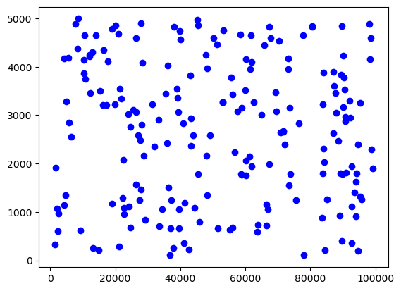

```python
plt.scatter(data['Impressions'], data['Clicks'], color='blue', label='Impressions vs Clicks')
plt.legend
plt.show()
```

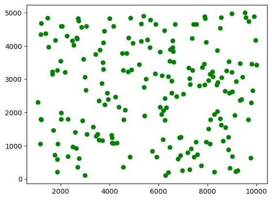

```python
plt.scatter(data['Budget (USD)'], data['Clicks'], color='green', label='Budget(USD) vs Clicks')
plt.legend
plt.show()
```

## Correlation

Correlation is a statistical measure that describes the strength and direction of a linear relationship between two variables. It indicates how closely two variables move together.

### Key Points:

- Positive Correlation: If one variable increases when the other increases, the correlation is positive.
- Negative Correlation: If one variable increases while the other decreases, the correlation is negative.
- Zero Correlation: If there's no linear relationship between the variables, the correlation is close to zero.

## Correlation Coefficient (r):

The correlation coefficient is a value between -1 and 1:

- +1: Perfect positive correlation.
- -1: Perfect negative correlation.
- 0: No correlation.

```python
# Correlation between Impressions and Clicks
correlation_impressions_clicks = data['Impressions'].corr(data['Clicks'])
```

```python
# Correlation between Budget (USD) and Clicks
correlation_budget_clicks = data['Budget (USD)'].corr(data['Clicks'])
```

```python
correlation_impressions_clicks, correlation_budget_clicks
```

```
(-0.0382753908931125, -0.027996814616415573)
```

### Interpretation:

- Correlation between Impressions and Clicks (−0.038):

The correlation is very close to 0 but slightly negative. This means that there is almost no linear relationship between impressions and clicks in your data. The small negative value suggests that as impressions increase, clicks very slightly tend to decrease, but the effect is negligible.

- Correlation between Budget (USD) and Clicks (−0.028):

Similarly, this correlation is also very close to 0, indicating almost no linear relationship between budget and clicks. The slight negative value implies that an increase in budget might be associated with a very small decrease in clicks, but this relationship is weak and almost insignificant.

### Conclusion:

Both correlations are very weak and near zero, indicating that impressions and budget do not have a strong linear relationship with clicks in this dataset. You might explore other factors or nonlinear relationships that could better explain the performance of your campaigns.